# Steve Walsh HW8

## Problem 2

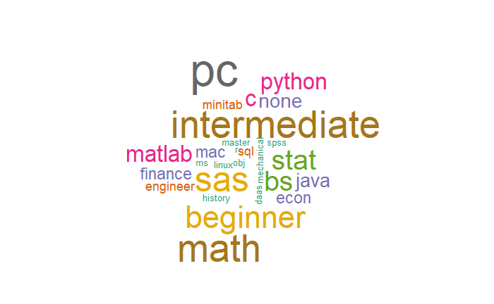

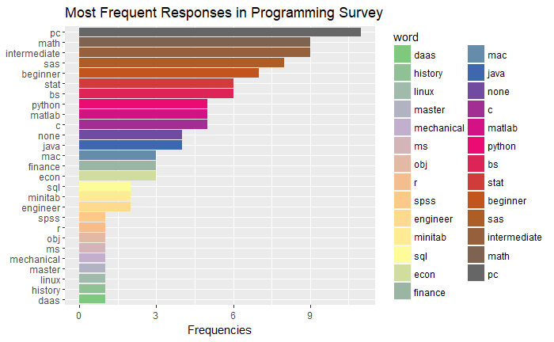

## Problem 3

The dataset I chose to analyze in this problem is based on thousands of responses to given football scenarios. One example of the many different scenarios include: “**It is first down and 10. The ball is on your opponent’s 40 yardline. There is 3 seconds left in the second quarter. You are down by 3 points. Would you:**”

Given the many different scenarios, I chose to look at portions of the scenarios that included whether it was first down and 10, the ball was on the opponents’ 20 yard line, there was three seconds left in the quarter, and the ball was on your 45 yard line. With the exception of the second and fourth portion, many of these overlap for multiple scenarios. Based on the word clouds and bar graphs, we can see that passing is certainly the most common choice if it is 1st and 10. When the ball is on the opponents’ 20 yard line, running the ball becomes the most popular while passing is a rather close second option. If there are three seconds left, passing is the most common selection by respondents, but kicking a field goal is not an uncommon selection in this scenario. Finally, for plays from your 45 yard line, running and passing are equally common selections. Don’t know, kneel down and punt are always rare selections given these four scenarios.

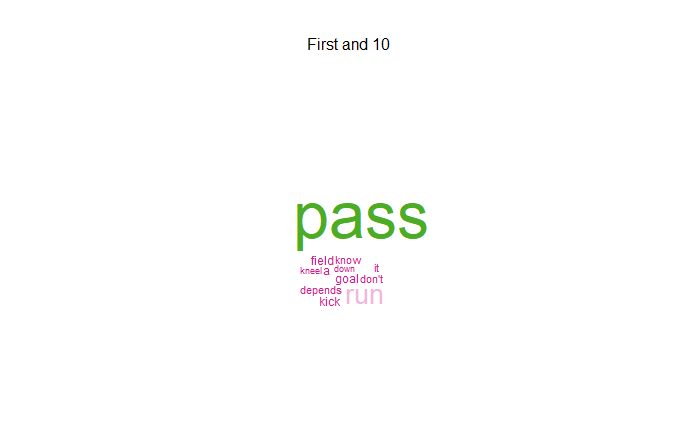

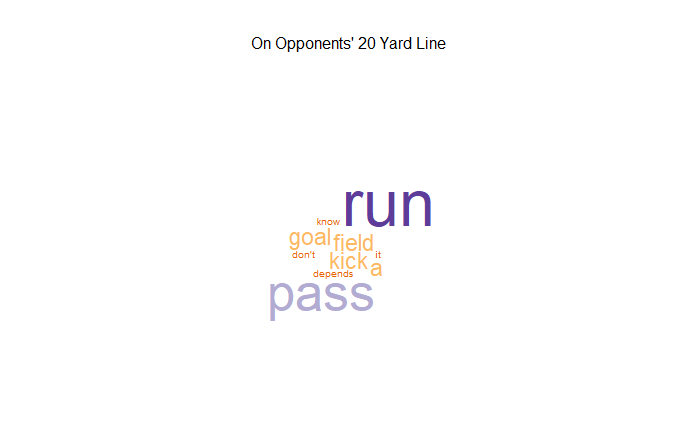

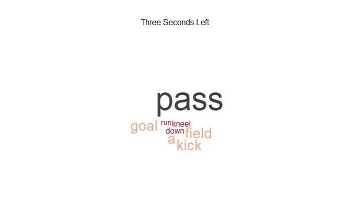

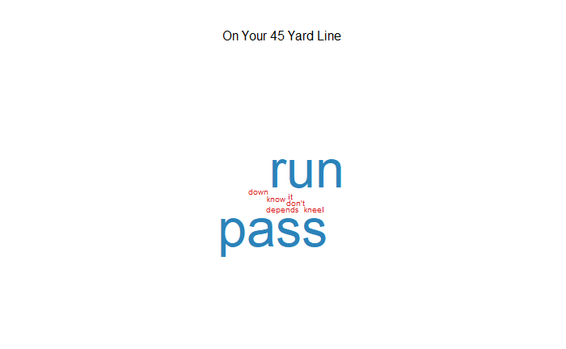

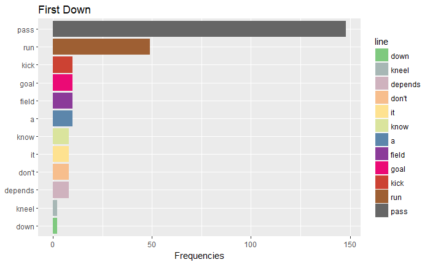

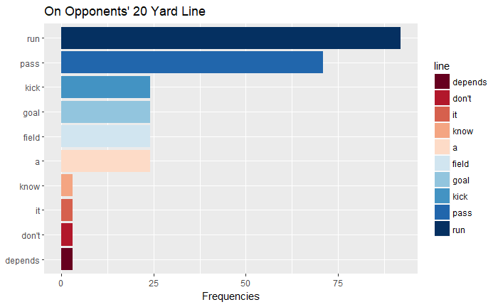

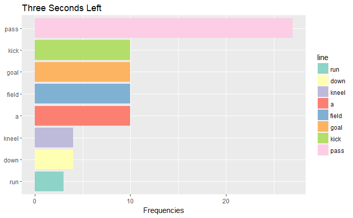

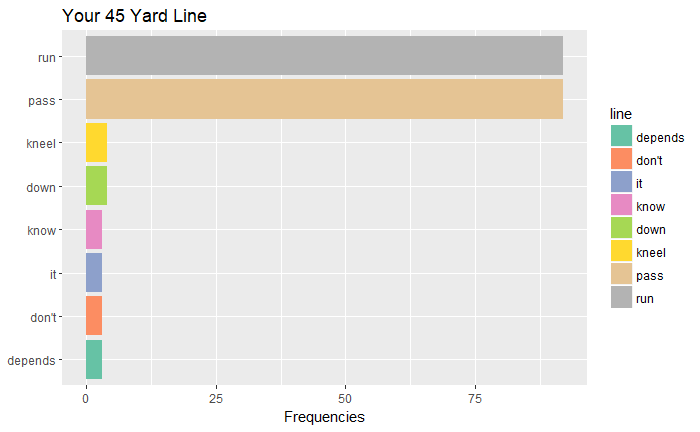

## Problem 4

I requested an account through ARC and now have an account for *DragonsTooth, Cascades, NewRiver* and *BlueRidge*.

## Appendix

```r
url <- "https://raw.githubusercontent.com/stevewalsh124/STAT_5014/master/08_text_mining_Rnotebooks_bash_sed_awk/survey_data.txt"
survey_words <- read.delim(url, header = T, fill = T, stringsAsFactors = F)
# survey_words

text_df1 <- data_frame(line = 1:14, text = survey_words[, 1])
text_df2 <- data_frame(line = 1:14, text = survey_words[, 2])
text_df3 <- data_frame(line = 1:14, text = survey_words[, 3])
text_df4 <- data_frame(line = 1:14, text = survey_words[, 4])
text_df <- rbind(text_df1, text_df2, text_df3, text_df4)
# text_df

new_text <- text_df[, 2] %>% unnest_tokens(word, text)  #%>% count(word, sort = T)
# new_text
new_lower <- tolower(new_text)
# new_lower class(new_lower)

tidy_text <- new_lower %>% str_replace_all("ineer", "") %>% str_replace_all("eng",
    "engineer") %>% str_replace_all("iate", "") %>% str_replace_all("ermed",
    "") %>% str_replace_all("int", "intermediate") %>% str_replace_all("inner",
    "") %>% str_replace_all("beg", "beginner") %>% str_replace_all("some", "") %>%
    str_replace_all("just", "") %>% str_replace_all("teeny", "") %>% str_replace_all("amount",
    "") %>% str_replace_all("of", "") %>% str_replace_all("surface", "") %>%
    str_replace_all("and", "")


# (tidy_text)
tidy_df <- data_frame(text = tidy_text)
# tidy_df
finishedtext <- tidy_df %>% unnest_tokens(word, text) %>% count(word, sort = T)
# finishedtext

# new_text %>% anti_join(stop_words) %>% count(word, sort =T)

finishedtext %>% with(wordcloud(word, n, min.freq = 1, max.words = 1500, colors = brewer.pal(8,
    "Dark2")))

finishedtext %>% mutate(word = reorder(word, n)) %>% ggplot(aes(word, n, fill = word)) +
    geom_col() + xlab(NULL) + ylab("Frequencies") + coord_flip() + ggtitle("Most Frequent Responses in Programming Survey") +
    scale_fill_manual(values = colorRampPalette(brewer.pal(8, "Accent"))(27))

# data provided from https://www.crowdflower.com/data-for-everyone/
football.data <- read.csv("~/R/Football-Scenarios-DFE-832307.csv")
football.data <- football.data[1:1000, ]
football.trim <- select(football.data, c("antecedent", "orig_antecedent"))
football.firstn10 <- filter(football.trim, grepl("It is first down and 10",
    orig_antecedent))
football.opp20 <- filter(football.trim, grepl("your opponent's 20 yardline.",
    orig_antecedent))
football.3sec <- filter(football.trim, grepl("3 seconds left in the fourth quarter",
    orig_antecedent))
football.ur45 <- filter(football.trim, grepl("your 45", orig_antecedent))


# I want to count the following five outcomes based on certain scenarios:
# c('kick a field goal','pass','run','don't know / it depends', 'kneel
# down', 'punt')

first10_df <- data_frame(text = tolower(football.firstn10[, 1])) %>% unnest_tokens(line,
    text) %>% count(line, sort = T)
opp20_df <- data_frame(text = tolower(football.opp20[, 1])) %>% unnest_tokens(line,
    text) %>% count(line, sort = T)
threesec_df <- data_frame(text = tolower(football.3sec[, 1])) %>% unnest_tokens(line,
    text) %>% count(line, sort = T)
ur45_df <- data_frame(text = tolower(football.ur45[, 1])) %>% unnest_tokens(line,
    text) %>% count(line, sort = T)

# 4 Word Clouds each with title
layout(matrix(c(1, 2), nrow = 2), heights = c(1, 4))
par(mar = rep(0, 4))
plot.new()
text(x = 0.5, y = 0.5, "First and 10")
first10_df %>% with(wordcloud(line, n, min.freq = 1, max.words = 1500, colors = brewer.pal(5,
    "PiYG")))
layout(matrix(c(1, 2), nrow = 2), heights = c(1, 4))
par(mar = rep(0, 4))
plot.new()
text(x = 0.5, y = 0.5, "On Opponents' 20 Yard Line")
opp20_df %>% with(wordcloud(line, n, min.freq = 1, max.words = 1500, colors = brewer.pal(5,
    "PuOr")))
layout(matrix(c(1, 2), nrow = 2), heights = c(1, 4))
par(mar = rep(0, 4))
plot.new()
text(x = 0.5, y = 0.5, "Three Seconds Left")
threesec_df %>% with(wordcloud(line, n, min.freq = 1, max.words = 1500, colors = brewer.pal(5,
    "RdGy")))
layout(matrix(c(1, 2), nrow = 2), heights = c(1, 4))
par(mar = rep(0, 4))
plot.new()
text(x = 0.5, y = 0.5, "On Your 45 Yard Line")
ur45_df %>% with(wordcloud(line, n, min.freq = 1, max.words = 1500, colors = brewer.pal(5,
    "Spectral")))

# Bar Plots
first10_df %>% mutate(line = reorder(line, n)) %>% ggplot(aes(line, n, fill = line)) +
    geom_col() + xlab(NULL) + ylab("Frequencies") + coord_flip() + ggtitle("First Down") +
    scale_fill_manual(values = colorRampPalette(brewer.pal(8, "Accent"))(12))
opp20_df %>% mutate(line = reorder(line, n)) %>% ggplot(aes(line, n, fill = line)) +
    geom_col() + xlab(NULL) + ylab("Frequencies") + coord_flip() + ggtitle("On Opponents' 20 Yard Line") +
    scale_fill_brewer(palette = "RdBu")
threesec_df %>% mutate(line = reorder(line, n)) %>% ggplot(aes(line, n, fill = line)) +
    geom_col() + xlab(NULL) + ylab("Frequencies") + coord_flip() + ggtitle("Three Seconds Left") +
    scale_fill_brewer(palette = "Set3")
ur45_df %>% mutate(line = reorder(line, n)) %>% ggplot(aes(line, n, fill = line)) +
    geom_col() + xlab(NULL) + ylab("Frequencies") + coord_flip() + ggtitle("Your 45 Yard Line") +
    scale_fill_brewer(palette = "Set2")
```